# Predicting Home Prices in King County

How different methods of analysis yield different results

Alexander Bell-Towne, Jack Fox, Sean Ker, Spencer Pease

March 8, 2017

## Purpose

The purpose of this resource is to show which covariates in our dataset influenced the price of a house. By identifying these covariates, we wanted to explore possible applications of our model in predicting house prices in real-world settings that buyers or sellers of real estate can leverage. A quantitative question we hoped to answer with our model is “which attribute(s) of a home directly correlates with the price of that home?” With this answer, sellers can direct their attention on providing the most value through those top attributes which correlate with price, in order to maximize profit. Buyers can also use this information to determine the type of house given a select amount of attributes that they can afford.

## Exploratory Data Analysis

Our dataset includes data from houses built between 1900 and 2015 in the King County, USA area. There are 21,613 observations of with 21 features, including some of the following:  
- Price of home (at a given Date) - Date (see above) - Number of bedrooms - Number of bathrooms - Square feet of living space - Square feet of the lot - Number of floors - Whether it is waterfront property - The grade of the view - The condition of the house - The grade of the house - Square feet of above ground living space - …

Below is snippet of the distributions for each feature in the data set

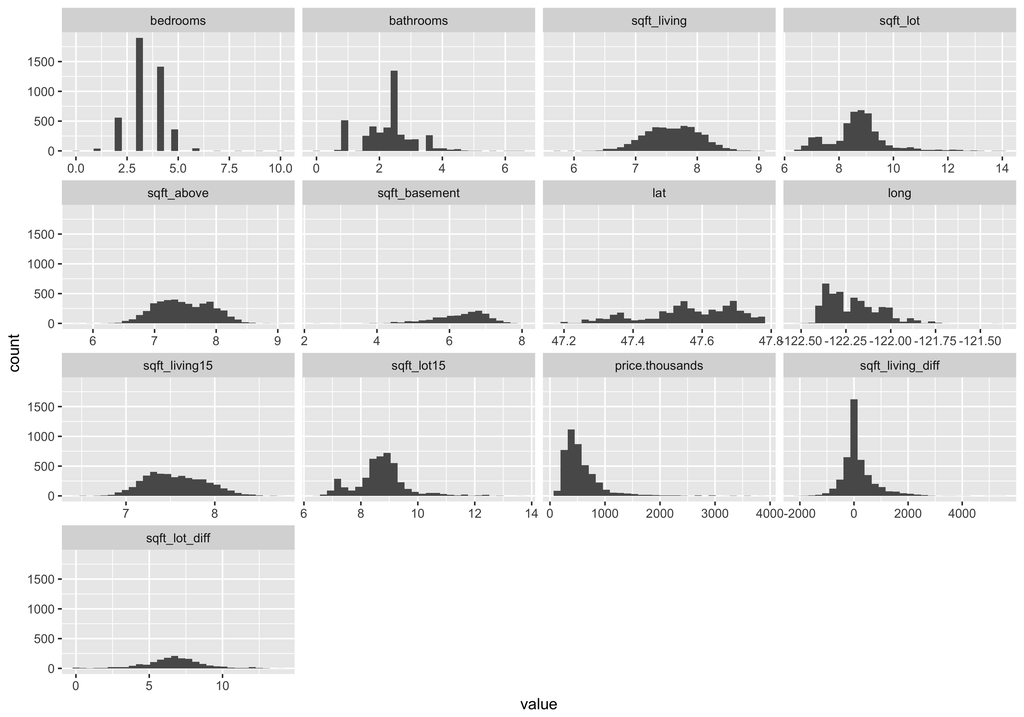

```
## # A tibble: 6 × 29
##           id       date  price bedrooms bathrooms sqft_living sqft_lot
##        <dbl>      <chr>  <dbl>    <int>     <dbl>       <int>    <int>
## 1 1974300020 -0/8-/2014 380000        4      2.50        2270    11500
## 2 1974300020 -0/2-/2015 624900        4      2.50        2270    11500
## 3 3630020380 -1/1-/2014 379770        3      2.50        1470     1779
## 4 1771000290 -1/2-/2014 340000        3      1.75        1280    16200
## 5 5126310470 -0/1-/2015 515500        4      2.75        2830     8126
## 6 1870400605 -1/1-/2014 600000        4      2.25        1970     7125
## # ... with 22 more variables: floors <fctr>, waterfront <lgl>,
## #   view <fctr>, condition <fctr>, grade <fctr>, sqft_above <int>,
## #   sqft_basement <int>, yr_built <fctr>, yr_renovated <fctr>,
## #   zipcode <fctr>, lat <dbl>, long <dbl>, sqft_living15 <int>,
## #   sqft_lot15 <int>, price.thousands <dbl>, sqft_living_diff <int>,
## #   sqft_lot_diff <int>, season <fctr>, prediction.all <dbl>,
## #   prediction.rsquare <dbl>, prediction.upper <dbl>,
## #   prediction.lower <dbl>
```

We discovered that some of the features in this dataset had major outliers. For example, the price feature had a maximum value of 7,700,000 and a minimum of 75,000

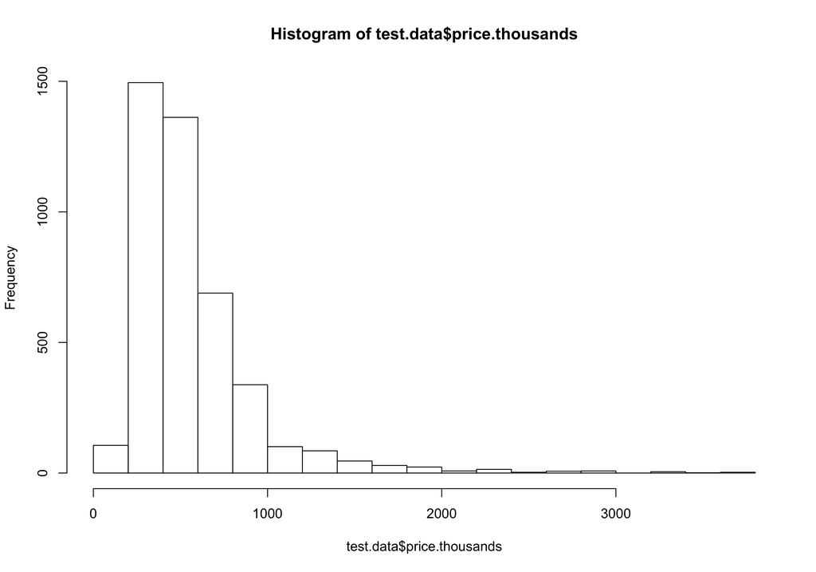

In addition, the number of bedrooms attribute also had major outliers, with a maximum value of 33 bedrooms and a mean of 3.371.

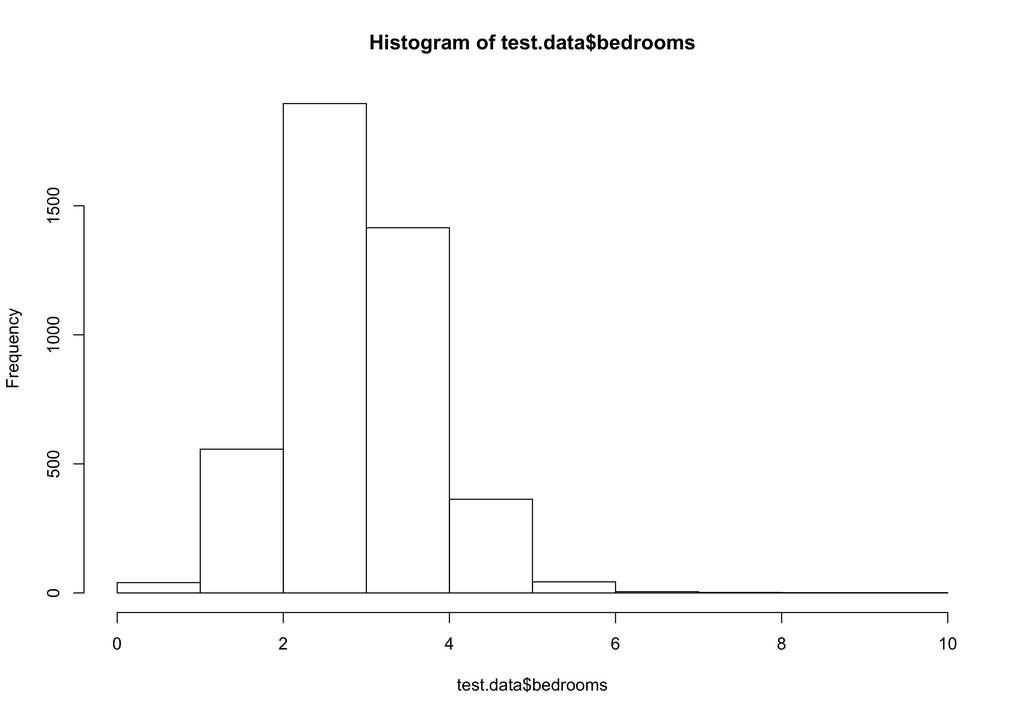